# problema1-cp3

Vinicius Brandão

## Conhecendo os dados analisado.

Para está analise será utilizado o conjunto de dados retirado do site [IMDB](https://www.imdb.com/) mais informações sobre o processor de importação e descrição dos dados pode ser encontradas [neste repositorio](https://github.com/nazareno/imdb-series).

```r
dados <- read_csv(here("data/series_from_imdb.csv"),
                    progress = FALSE,
                    col_types = cols(.default = col_double(),
                                     series_name = col_character(),
                                     episode = col_character(),
                                     url = col_character(),
                                     season = col_character()))
```

Para está analise utilizamos como critério de escolha o mesmo número de temporada para todas as séries escolhidas e desse modo escolhemos as seguintes:

- The Blacklist
- House of Cards
- Vikings

## Conhecendo os dados da analise.

Para conhecer melhor sobre os dados das séries escolhidas, iremos plotar um gráfico em pontos e desse modo verificar a existência de algum valor considerado extremo discrepante.

```r
 dados_escolhidos %>%
    ggplot(aes(x= series_name,
               y = user_rating,
               color=series_name)) +
    geom_boxplot(width = .5,
                 outlier.color = NA) +
    geom_jitter(width = 0.2) +
    labs(y = "Ratings dos usuários", x = "Séries Escolhidas")
```

[output not shown]

## Explicação sobre estimadores utilizados

Para está analise o objetivo é responder as seguintes perguntas:

- A temporada mais bem avaliada da série possui uma maior proporção de notas 10?
- Os episódios que recebem mais votos dos usuários são episódios bom/ruins?

Com isso, utilizaremos alguns conceitos como :

- Média : é a soma dos valores dos elementos de um conjunto dividido pelo número de elementos nesse conjunto.
- Mediana : é o valor que separa a metade maior e a metade menor de uma amostra.
- Correlação : é qualquer relação dentro de uma ampla classe de relações estatísticas que envolva dependência entre duas variáveis. Tendo como parametro os valores entre -1 e 1, considerando que os valores porximos de 0 como correlação fraca e os valores proximos de -1 e 1 como fortes.

## As temporadas mais bem avaliadas das séries possuem uma maior proporção de notas 10?

Para está pergunta iremos analisar as médias de cada temporada e desse modo verificar qual temporada de cada série foi a mais bem avaliada.

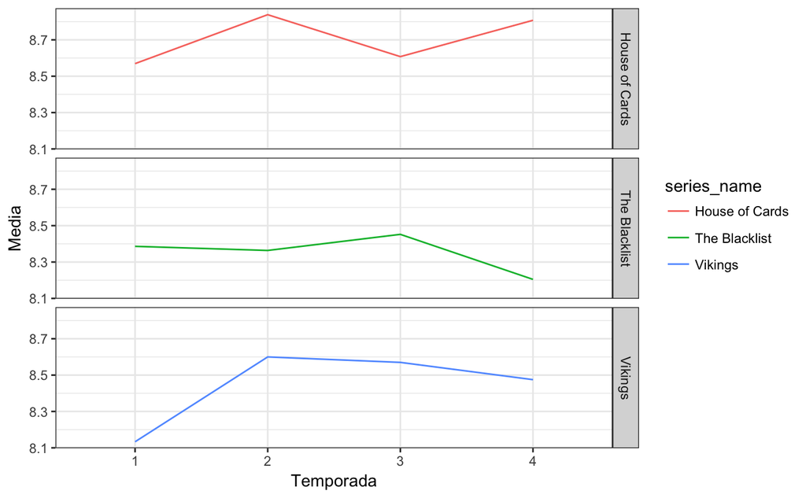

```r
  dados_escolhidos %>%
  group_by(series_name,
           season) %>%
  summarise(media = mean(user_rating)) %>%
  ggplot(aes(x = season,
             y = media,
               color = series_name,
               group = series_name)) +
    geom_line() +
   facet_grid(series_name ~ .) +
     labs(y = "Media", x = "Temporada")
```

Como podemos observa no gráfico acima, temos para cada série sua respectiva temporada mais bem avaliada em relação á sua média:

| Série | Temporada |
| --- | --- |
| House of Cards | 2 |
| The Blacklist | 3 |
| Vikings | 2 |

Diante dessa informação, iremos calcular a proporção de notas 10 em relação às temporadas de cada série, sabendo que a proporção é frequência relativa(Resultado da divisão da frequência absoluta) com que a nota 10 está presente por temporada.

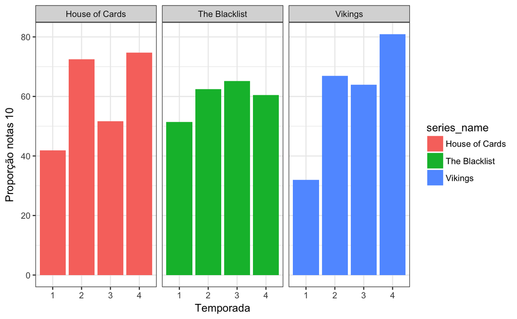

```r
dados_escolhidos %>%
    ggplot(aes(x = season,
               y = r10 * 100,
               fill = series_name)) +
    geom_col(position = "identity") +
    facet_wrap(~ series_name) +
  labs(y = "Proporção notas 10", x= "Temporada")
```

Como podemos observa no gráfico acima, temos a seguinte temporada com maior proporção de notas 10:

| Série | Temporada |
| --- | --- |
| House of Cards | 4 |
| The Blacklist | 3 |
| Vikings | 4 |

Diante dessa analise nos veio a pergunta: *Por que Vikings possui uma maior proporção de nota 10 na 4 temporada e sua 2 temporada é a mais bem avaliada*

Para responder essa perguntas observamos o séguinte gráfico.

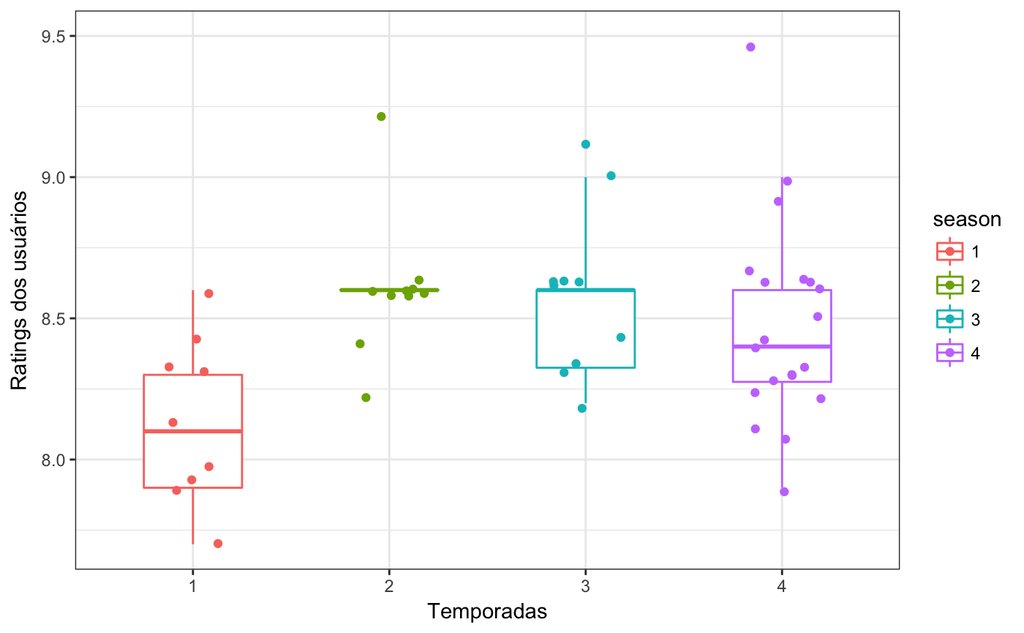

```r
 dados_escolhidos %>%
    filter(series_name == "Vikings") %>%
    ggplot(aes(x= season,
               y = user_rating,
               color=season)) +
    geom_boxplot(width = .5,
                 outlier.color = NA) +
    geom_jitter(width = 0.2) +
    labs(y = "Ratings dos usuários", x = "Temporadas")
```

Como podemos observar á 4 temporada tem mais episódios do que as demais temporadas e observamos que a concentração e a média das notas é inferior a da 2 temporada que podemos observar que possui uma concentração maior em torno de sua média, por isso temos que na 4 temporada uma proporção maior de nota 10, mas os outros episódios não tendem a seguir notas altas e assim a média da 4 temporada é inferior.

## Conclusão

Diante do que foi exposto acima observamos que ocorreu uma diferença em relação às temporadas mais bem avaliadas e a proporção de notas 10 por temporada, observado os casos da série House of Cards e Vikings observamos que as suas temporadas melhor avaliadas não foram as mesmas que obtiveram uma proporção maior de notas 10 e desse modo vemos que não existe uma relação para esse conjunto de dados em relação às temporadas melhor avaliada e a proporção de notas 10.

## Os episódios que recebem mais votos dos usuários são episódios bom/ruins

Pra responder essa pergunta iremos observar o número de votos recebido por episódio e as notas atribuidas para desse modo verifica a relação dos votos com sua definição(bom/ruim).

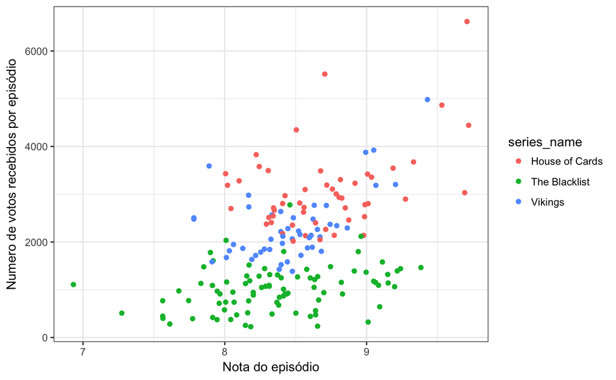

```r
dados_escolhidos %>%
  arrange(-user_votes) %>%
  ggplot(aes(x = user_rating,y = user_votes,color = series_name)) +
  geom_jitter(width = 0.2) +
  labs(y = "Numero de votos recebidos por episódio", x ="Nota do episódio")
```

Para melhorar nossa avaliação iremos separar do conjunto de dados apenas os 10 episódios mais bem avaliados.

```r
  top_10_avaliados <- dados_escolhidos %>% arrange(-user_votes) %>% top_n(10)
```

```r
 cor(top_10_avaliados$user_votes,(top_10_avaliados$r9 + top_10_avaliados$r10))
```

```
[1] 0.5342029
```

Como observamos o valor acima temos uma correção *moderada* dado que a correlação é medido entre -1 e 1 e só consideramos uma correlação fraca com valores próximos á 0 e só é forte com valores próximos á 1 ou -1. Assim iremos calcular agora á correlação da proporção de episódios ruins(Episódios entre 1 e 2) e os 10 episódios mais bem votados da amostra.

```r
cor(top_10_avaliados$user_votes,(top_10_avaliados$r1 + top_10_avaliados$r2))
```

```
[1] 0.01743553
```

Observamos que é uma correlação muito fraca entre as variáveis dando assim que a relação entre os episódios bem votados e os episódios ruins como *fraca*.

## Conclusão

### O episódios considerados ruins tendem a ser os menos votados pelos usuários

Para melhorar nossa avaliação iremos separar do conjunto de dados apenas os 10 episódios que menos foram avaliados.

```r
  downn_10_avaliacao <- dados_escolhidos %>% arrange(user_votes) %>% slice(c(1:10))
```

Para conhecer melhor os 10 episódios menos votados pelo usuários temos:

```r
downn_10_avaliacao
```

| series_name | episode | series_ep | season | season_ep | url | user_rating | user_votes | r1 | r2 | r3 | r4 | r5 | r6 | r7 | r8 | r9 | r10 |
| --- | --- | --- | --- | --- | --- | --- | --- | --- | --- | --- | --- | --- | --- | --- | --- | --- | --- |
| The Blacklist | The Debt Collector (No. 46) | 87 | 4 | 20 | http://www.imdb.com/title/tt6769268/ | 8.3 | 225 | 0.008733624 | 0.017467249 | 0.013100437 | 0.013100437 | 0.021834061 | 0.03930131 | 0.07860262 | 0.2401747 | 0.2925764 | 0.2751092 |
| The Blacklist | Mr. Kaplan (No. 4) | 88 | 4 | 21 | http://www.imdb.com/title/tt6769298/ | 8.7 | 236 | 0.008333333 | 0.008333333 | 0.012500000 | 0.008333333 | 0.008333333 | 0.02916667 | 0.04166667 | 0.1833333 | 0.3291667 | 0.3708333 |
| The Blacklist | Dr. Bogdan Krilov (No. 29) | 86 | 4 | 19 | http://www.imdb.com/title/tt6668958/ | 8.0 | 253 | 0.007874016 | 0.007874016 | 0.015748031 | 0.011811024 | 0.023622047 | 0.05118110 | 0.11811024 | 0.3858268 | 0.1771654 | 0.2007874 |
| The Blacklist | Philomena (No. 61) | 85 | 4 | 18 | http://www.imdb.com/title/tt6626200/ | 7.8 | 282 | 0.017667845 | 0.024734982 | 0.021201413 | 0.021201413 | 0.024734982 | 0.03886926 | 0.13427562 | 0.3286219 | 0.1872792 | 0.2014134 |
| The Blacklist | Mr. Kaplan (No. 4): Conclusion | 89 | 4 | 22 | http://www.imdb.com/title/tt6769302/ | 9.2 | 323 | 0.006042296 | 0.009063444 | 0.009063444 | 0.006042296 | 0.006042296 | 0.01812689 | 0.02719033 | 0.0755287 | 0.2386707 | 0.6042296 |
| The Blacklist | The Architect (No. 107) | 81 | 4 | 14 | http://www.imdb.com/title/tt6443932/ | 7.8 | 373 | 0.017632242 | 0.015113350 | 0.017632242 | 0.017632242 | 0.017632242 | 0.07052897 | 0.15113350 | 0.3526448 | 0.1586902 | 0.1813602 |
| The Blacklist | Isabella Stone (No. 34) | 80 | 4 | 13 | http://www.imdb.com/title/tt6441958/ | 8.0 | 376 | 0.008865248 | 0.008865248 | 0.007092199 | 0.010638298 | 0.008865248 | 0.02304965 | 0.04787234 | 0.1117021 | 0.2890071 | 0.4840426 |
| The Blacklist | Natalie Luca (No. 184) | 79 | 4 | 12 | http://www.imdb.com/title/tt6439022/ | 7.8 | 394 | 0.013227513 | 0.013227513 | 0.013227513 | 0.015873016 | 0.037037037 | 0.06084656 | 0.15343915 | 0.3227513 | 0.1507937 | 0.2195767 |
| The Blacklist | The Forecaster (No. 163) | 77 | 4 | 10 | http://www.imdb.com/title/tt6210144/ | 7.7 | 399 | 0.014925373 | 0.014925373 | 0.017412935 | 0.017412935 | 0.032338308 | 0.07960199 | 0.17412935 | 0.3457711 | 0.1218905 | 0.1815920 |
| The Blacklist | The Harem (No. 102) | 78 | 4 | 11 | http://www.imdb.com/title/tt6257202/ | 7.8 | 419 | 0.035545024 | 0.004739336 | 0.011848341 | 0.009478673 | 0.040284360 | 0.08767773 | 0.16587678 | 0.3601896 | 0.1042654 | 0.1800948 |

Observamos que todos os episódios são da mesma série e da mesma temporada.

Para temos uma precisão melhor na resposta iremos medir a correlação, tendo em vista que episódio considerado ruins com notas inferiores a 5 ou com proporção entre 1 e 2. Para isso temos:

```r
cor(downn_10_avaliacao $user_votes,(downn_10_avaliacao $r1 + downn_10_avaliacao $r2))
```

```
[1] 0.3621035
```

Observamos uma correlaçao fraca/moderada.

Para melhorar iremos plotar um gráfico e observa como as notas estão sendo distribuídas para esse conjunto.

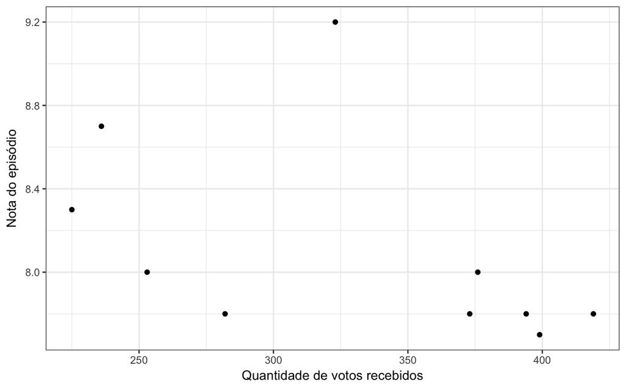

```r
downn_10_avaliacao %>%
  ggplot(aes(x = user_votes,
             y= user_rating)) +
  geom_point() +
  labs(y= "Nota do episódio", x = "Quantidade de votos recebidos")
```

Como podemos observa no gráfico acima, os episódios menos votados possui notas superiores a 7 e observamos também que tem um episódio que recebeu nota 9,2 que para essa analise o episódio é considerado como bom. Desse modo verificamos que não existe uma relação para que os episódios menos votas implica que os episódios é ruim.